# Final Exam

Chico Bonilla

April 24, 2019

# Part I

Let’s take a look at some data provided by the Virginia Institue of Marine Science. We’ll be taking a look at the Chesapeake Bay and seeing if light attenuation can be explained by a number of predictor variables. Specifically, we’ll be taking a look at the salinity, pH, dissolved oxygen, chlorophyll content, turbidity, and the depth of the water as well as the water temperature. Our goal here is to try to make a model that explains the light attenuation, labeled as Kd, using these seven variables. Let’s first take a look at some histograms to understand the data.

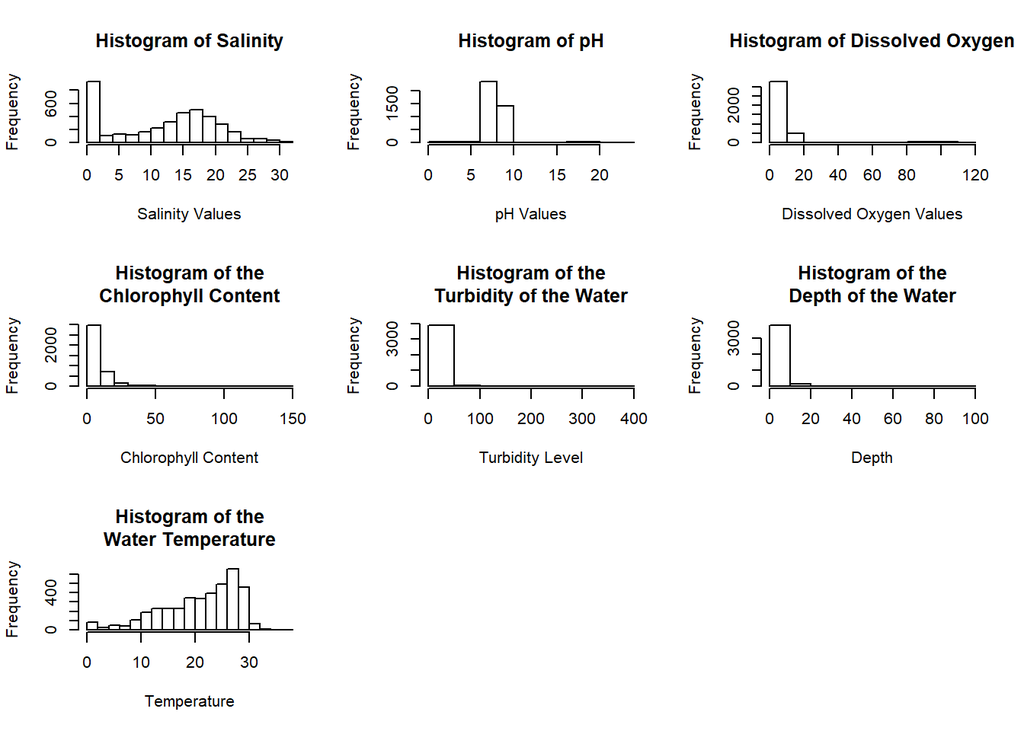

I’m worried about the variables dissolved oxygen, turbidity, and depth. The variable dissolved oxygen may have some outliers. Turbidity and depth also seem to have outliers. The pH graph also looks a little strange, but nothing immediately worrying. Let’s continue by fitting a model. We’ll do this by using the step function. What this step function does is it starts with a model that explains Kd by nothing at all, and slowly adds a variable at a time until adding a variable wouldn’t be a significant enough change. The process can be seen below.

```
## Start:  AIC=1937.99
## river$Kd ~ 1
##
##                         Df Sum of Sq    RSS     AIC
## + river$YSI.Turbidity    1    3329.4 3117.4 -928.61
## + river$YSI.Salinity     1    1421.9 5024.8  956.20
## + river$YSI.Chlorophyll  1    1172.4 5274.4 1147.54
## + river$YSI.pH           1     370.4 6076.3 1706.35
## + river$YSI.WTemp        1      96.2 6350.6 1880.63
## <none>                               6446.8 1937.99
## + river$Depth            1       0.4 6446.4 1939.75
## + river$YSI.DO           1       0.2 6446.5 1939.83
##
## Step:  AIC=-928.61
## river$Kd ~ river$YSI.Turbidity
##
##                         Df Sum of Sq    RSS      AIC
## + river$YSI.Chlorophyll  1    457.89 2659.5 -1553.78
## + river$YSI.Salinity     1    240.87 2876.5 -1244.09
## + river$YSI.pH           1    159.40 2958.0 -1133.82
## + river$YSI.DO           1     22.35 3095.0  -955.02
## + river$YSI.WTemp        1     20.10 3097.3  -952.14
## <none>                               3117.4  -928.61
## + river$Depth            1      0.71 3116.7  -927.51
##
## Step:  AIC=-1553.78
## river$Kd ~ river$YSI.Turbidity + river$YSI.Chlorophyll
##
##                      Df Sum of Sq    RSS     AIC
## + river$YSI.Salinity  1   210.553 2448.9 -1877.4
## + river$YSI.pH        1   128.570 2530.9 -1747.4
## + river$YSI.WTemp     1    12.004 2647.5 -1569.6
## + river$YSI.DO        1     2.866 2656.6 -1556.0
## <none>                            2659.5 -1553.8
## + river$Depth         1     0.531 2658.9 -1552.6
##
## Step:  AIC=-1877.41
## river$Kd ~ river$YSI.Turbidity + river$YSI.Chlorophyll + river$YSI.Salinity
##
##                   Df Sum of Sq    RSS     AIC
```

[output cut: 21 more lines]

```
## + river$YSI.WTemp  1   19.8605 2251.2 -2203.8
## + river$Depth      1    4.1878 2266.9 -2176.4
## <none>                         2271.1 -2171.1
##
## Step:  AIC=-2203.76
## river$Kd ~ river$YSI.Turbidity + river$YSI.Chlorophyll + river$YSI.Salinity +
##     river$YSI.pH + river$YSI.DO + river$YSI.WTemp
##
##               Df Sum of Sq    RSS     AIC
## + river$Depth  1    4.8607 2246.3 -2210.3
## <none>                     2251.2 -2203.8
##
## Step:  AIC=-2210.29
## river$Kd ~ river$YSI.Turbidity + river$YSI.Chlorophyll + river$YSI.Salinity +
##     river$YSI.pH + river$YSI.DO + river$YSI.WTemp + river$Depth
```

```
##
## Call:
## lm(formula = river$Kd ~ river$YSI.Turbidity + river$YSI.Chlorophyll +
##     river$YSI.Salinity + river$YSI.pH + river$YSI.DO + river$YSI.WTemp +
##     river$Depth)
##
## Coefficients:
##           (Intercept)    river$YSI.Turbidity  river$YSI.Chlorophyll
##               2.00071                0.05947                0.03443
##    river$YSI.Salinity           river$YSI.pH           river$YSI.DO
##              -0.03400               -0.11578                0.01271
##       river$YSI.WTemp            river$Depth
##               0.01276               -0.01246
```

The step function tells us that all seven of our variables are significant enough to include in our model. We’ll continue our analysis with this model.

Next, let’s see if we are worried about collinearity between any of our variables. We will do this by using the VIF function. This will give us a value between 1 and infinity for each variable. We’re worried if any variable has a VIF value above 10. Let’s take a look at that now.

```
##    river$YSI.Salinity          river$YSI.pH          river$YSI.DO
##              1.373353              1.122790              1.763310
## river$YSI.Chlorophyll   river$YSI.Turbidity           river$Depth
##              1.128148              1.256895              1.026685
##       river$YSI.WTemp
##              1.551442
```

Looking at these values, we’re not concerned with collinearity.

Now let’s talk about ridge and lasso regression. Ridge and Lasso regression are different regression methods that we can use if we are concerned with our assumptions and, specifically, collinear data. For this problem, it is not appropriate to use either method as our assumptions can be fixed with transformations and removal of outliers, and we do not have any concerns with collinearity. We’ll stick with linear regression.

Let’s now look closer at any possible outliers. We can do this by looking at the leverage and Cook’s values. These values deal with the residuals of the model, and high values are indicators of outliers. Let’s look at those now.

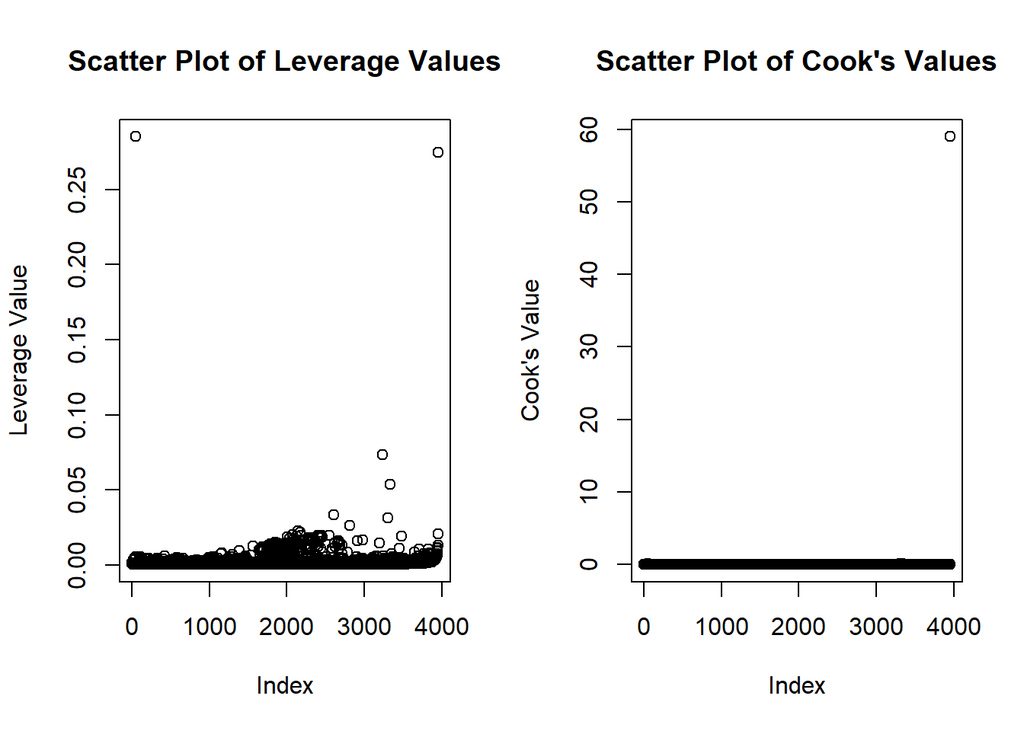

It looks like there may be a few outliers. We can simply remove them and remake our model with the new data.

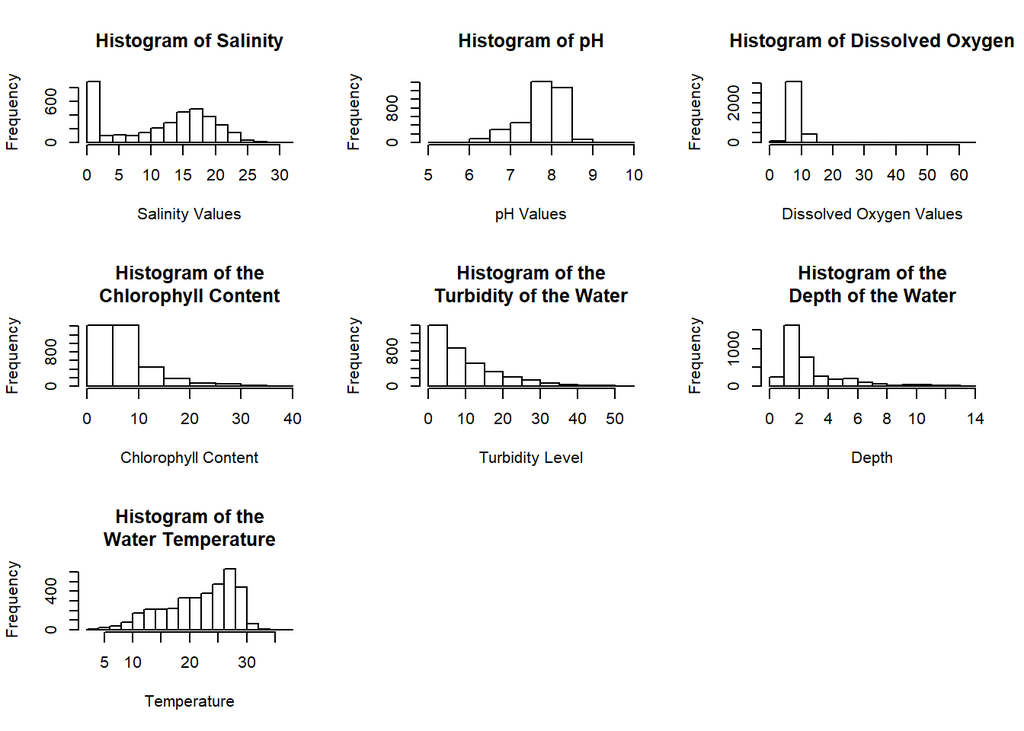

Still a bit of a skew, but I’m less worried about any violations in assumptions.

Finally, let’s look more specifically at what our model tells us.

```
##
## Call:
## lm(formula = river.rmv$Kd ~ river.rmv$YSI.Salinity + river.rmv$YSI.pH +
##     river.rmv$YSI.DO + river.rmv$YSI.Chlorophyll + river.rmv$YSI.Turbidity +
##     river.rmv$Depth + river.rmv$YSI.WTemp)
##
## Residuals:
##     Min      1Q  Median      3Q     Max
## -3.5182 -0.2057 -0.0444  0.1384 11.7069
##
## Coefficients:
##                             Estimate Std. Error t value Pr(>|t|)
## (Intercept)                4.2898645  0.1915448  22.396  < 2e-16 ***
## river.rmv$YSI.Salinity    -0.0082592  0.0017150  -4.816 1.53e-06 ***
## river.rmv$YSI.pH          -0.4745942  0.0291264 -16.294  < 2e-16 ***
## river.rmv$YSI.DO           0.0052384  0.0078945   0.664 0.507015
## river.rmv$YSI.Chlorophyll  0.0483074  0.0020067  24.073  < 2e-16 ***
## river.rmv$YSI.Turbidity    0.0816312  0.0013095  62.336  < 2e-16 ***
## river.rmv$Depth           -0.0007242  0.0044858  -0.161 0.871745
## river.rmv$YSI.WTemp        0.0087657  0.0022837   3.838 0.000126 ***
## ---
## Signif. codes:  0 '***' 0.001 '**' 0.01 '*' 0.05 '.' 0.1 ' ' 1
##
## Residual standard error: 0.5621 on 3621 degrees of freedom
## Multiple R-squared:  0.7752, Adjusted R-squared:  0.7747
## F-statistic:  1783 on 7 and 3621 DF,  p-value: < 2.2e-16
```

# Part II

Now let’s take a look at some American football data. This data set focuses on kickers in their field goal attempts. Here, since we’re explaining a binary variable (one that only takes a value of 0 or 1), we can’t use linear regression. Instead, we’ll use logistic regression to help us understand this data. We’ll also want to make two different models, one for the AFL kicking performances and one for the NFL kicking performances. Let’s take a look at both models now

```
##
## Call:
## glm(formula = kick.nfl$Made ~ kick.nfl$Distance + kick.nfl$Dist2,
##     family = binomial)
##
## Deviance Residuals:
##     Min       1Q   Median       3Q      Max
## -2.0545  -0.7610   0.5083   0.7068   2.1825
##
## Coefficients:
##                    Estimate Std. Error z value Pr(>|z|)
## (Intercept)        2.490203   1.018619   2.445   0.0145 *
## kick.nfl$Distance -0.013167   0.065990  -0.200   0.8419
## kick.nfl$Dist2    -0.001513   0.001008  -1.500   0.1335
## ---
## Signif. codes:  0 '***' 0.001 '**' 0.01 '*' 0.05 '.' 0.1 ' ' 1
##
## (Dispersion parameter for binomial family taken to be 1)
##
##     Null deviance: 637.73  on 460  degrees of freedom
## Residual deviance: 491.37  on 458  degrees of freedom
## AIC: 497.37
##
## Number of Fisher Scoring iterations: 4
```

```
##
## Call:
## glm(formula = kick.afl$Made ~ kick.afl$Distance + kick.afl$Dist2,
##     family = binomial)
##
## Deviance Residuals:
##     Min       1Q   Median       3Q      Max
## -2.2189  -0.8981   0.4223   0.7822   1.6281
##
## Coefficients:
##                    Estimate Std. Error z value Pr(>|z|)
## (Intercept)        4.892466   1.189215   4.114 3.89e-05 ***
## kick.afl$Distance -0.197046   0.074346  -2.650  0.00804 **
## kick.afl$Dist2     0.001604   0.001098   1.461  0.14394
## ---
## Signif. codes:  0 '***' 0.001 '**' 0.01 '*' 0.05 '.' 0.1 ' ' 1
##
## (Dispersion parameter for binomial family taken to be 1)
##
##     Null deviance: 438.59  on 321  degrees of freedom
## Residual deviance: 361.33  on 319  degrees of freedom
## AIC: 367.33
##
## Number of Fisher Scoring iterations: 4
```

Looking at the coefficients, we can see that in both models, distance has a negative coefficient. In practical terms, this means that the longer the distance, the lower the chance of making the field goal. The AFL also seems to have a higher probability of making a field goal than the NFL based on the intercept, or $\beta_0$, coefficient being larger in the AFL set. Also, the quadratic variable affects the model differently in the sets as well, with it having a negative impact in the NFL set and a positive yet small impact in the AFL set. Overall, from a first glance it seems that AFL kickers in general have a higher chance of making a field goal than those of the NFL.

Let’s now look at a model that includes both leagues.

```
##
## Call:
## glm(formula = fg1$Made ~ fg1$Distance + fg1$Dist2 + fg1$Z, family = binomial)
##
## Deviance Residuals:
##     Min       1Q   Median       3Q      Max
## -2.1534  -0.8425   0.4552   0.7547   1.9566
##
## Coefficients:
##                Estimate Std. Error z value Pr(>|z|)
## (Intercept)   3.5241844  0.7747793   4.549  5.4e-06 ***
## fg1$Distance -0.0958710  0.0490209  -1.956   0.0505 .
## fg1$Dist2    -0.0001086  0.0007365  -0.147   0.8828
## fg1$Z         0.1037533  0.1698309   0.611   0.5413
## ---
## Signif. codes:  0 '***' 0.001 '**' 0.01 '*' 0.05 '.' 0.1 ' ' 1
##
## (Dispersion parameter for binomial family taken to be 1)
##
##     Null deviance: 1078.27  on 782  degrees of freedom
## Residual deviance:  858.73  on 779  degrees of freedom
## AIC: 866.73
##
## Number of Fisher Scoring iterations: 4
```

In the combined model, both the distance and quadratic variable negatively impact the kicker’s probability of making a field goal. However, we can also see that the quadratic variable is not very significant for our model at all, with a p-value of 0.8828, well over our $\alpha$ of $0.05$.

Finally, let’s see if the leagues have different probabilities of scoring field goals. We can do this by using a t-test to compare the probabilities of making a field goal for each league.

```
##
##  Welch Two Sample t-test
##
## data:  kick.nfl$expected and kick.afl$expected
## t = -2.8116, df = 748.68, p-value = 0.005059
## alternative hypothesis: true difference in means is not equal to 0
## 95 percent confidence interval:
##  -0.08580272 -0.01524685
## sample estimates:
## mean of x mean of y
## 0.5271150 0.5776398
```

Our t-test shows that there is a difference in the probability of scoring a field goal in different leagues.